# Views

Bernardo Reckziegel

2022-09-29

This vignette provides a “jump-start” for users that want to quickly understand how to use entropy-pooling (EP) to construct *views* on the market distribution. The methodology fits well in a variety of scenarios: stress-testing, macro factors, non-linear payoffs, and more.

To demonstrate entropy-pooling’s firepower, the current vignette uses some of the cases Meucci (2008)[^1] leaves for the reader in the appendix. In particular, the usage of the following functions are covered in depth:

- `view_on_mean()`
- `view_on_volatility()`
- `view_on_correlation()`
- `view_on_rank()`
- `view_on_marginal_distribution()`
- `view_on_copula()`

Along with the examples, the `EuStockMarkets` dataset - that comes with the installation of `R` - is used as a *proxy* for “the market”:

```r
library(ffp)
library(ggplot2)
set.seed(321)

# invariance / stationarity
x <- diff(log(EuStockMarkets))

dim(x)
```

```
#> [1] 1859    4
```

```r
head(x)
```

```
#>               DAX          SMI          CAC         FTSE
#> [1,] -0.009326550  0.006178360 -0.012658756  0.006770286
#> [2,] -0.004422175 -0.005880448 -0.018740638 -0.004889587
#> [3,]  0.009003794  0.003271184 -0.005779182  0.009027020
#> [4,] -0.001778217  0.001483372  0.008743353  0.005771847
#> [5,] -0.004676712 -0.008933417 -0.005120160 -0.007230164
#> [6,]  0.012427042  0.006737244  0.011714353  0.008517217
```

## Views on Expected Returns

Assume an investor believes the `FTSE` index return will be $20\%$ above average in the near future. In order to process this *view*, the investor needs to minimize the relative entropy:

$$\sum_{j=1}^J x_j(ln(x_j) - ln(p_j))$$

Subject to the restriction:

$$\ x_j V_{j, k} = \mu_{k}$$

In which $x_{j}$ is a yet to be discovered *posterior* probability; $V_{j,k}$ is a $1859 \times 1$ vector with the `FTSE` returns; and $\mu_{k}$ is a $1 \times 1$ scalar with the investor projected return for the `FTSE` index. In this case, the $k$ subscript represents the fourth column in `x`[^2].

*Views* on expected returns can be constructed with `view_on_mean`:

```r
# Returns 20% higher than average
mu <- mean(x[ , "FTSE"]) * 1.2

# ffp views constructor
views <- view_on_mean(x = as.matrix(x[ , "FTSE"]), mean = mu)
views
```

```
#> # ffp view
#> Type:  View On Mean
#> Aeq :  Dim 1 x 1859
#> beq :  Dim 1 x 1
```

The `views` object is a `list` with two components, `Aeq` and `beq`, that are equivalent to the elements $V_{j,k}$ transposed and $\mu_{k}$, respectively.

The investor also needs to formulate a vector of *prior* probabilities, $p_j$, which is usually - but not necessary - a equal-weight vector:

```r
# Prior probabilities
p_j <- rep(1 / nrow(x), nrow(x))
```

Once the *prior* and the *views* are established, the optimization can take place with `entropy_pooling`:

```r
# Solve Minimum Relative Entropy (MRE)
ep <- entropy_pooling(
  p      = p_j,
  Aeq    = views$Aeq,
  beq    = views$beq,
  solver = "nlminb"
)
ep
```

```
#> <ffp[1859]>
#> 0.0005425631 0.0005340012 0.000544236 0.0005418246 0.0005322989 ... 0.0005451271
```

What is the interpretation for `ep`? Among all the possible probability vectors, `ep` is the one that can satisfy the *views* in the “least” evasive way (in which the term “least evasive” is direct reference to the *prior*). Therefore, `ep` is the best candidate for a *posterior* distribution.

In real world, the investor can have many *views*. Extending the current example, say the investor has a new belief: the `CAC` index returns will be $10\%$ bellow average[^3]:

```r
mu <- c(
  mean(x[ , "FTSE"]) * 1.2, # Return 20% higher than average
  mean(x[ , "CAC"]) * 0.9   # Return 10% bellow average
)

# ffp views constructor
views <- view_on_mean(x = as.matrix(x[ , c("FTSE", "CAC")]), mean = mu)
views
```

```
#> # ffp view
#> Type:  View On Mean
#> Aeq :  Dim 2 x 1859
#> beq :  Dim 2 x 1
```

In which the elements `Aeq` and `beq` now have $2$ rows each, one for every *view*.

The minimum relative entropy problem is solved in the exact same way:

```r
# Solve MRE
ep <- entropy_pooling(
  p      = p_j,
  Aeq    = views$Aeq,
  beq    = views$beq,
  solver = "nlminb"
)
ep
```

```
#> <ffp[1859]>
#> 0.0005602371 0.0005473082 0.0005573006 0.0005384979 0.000531066 ... 0.0005434801
```

It’s easier to analyse the output of `ep` visually.

```r
class(ep)
```

```
#> [1] "ffp"        "vctrs_vctr"
```

To that end, the `autoplot` method is available for objects of the `ffp` class:

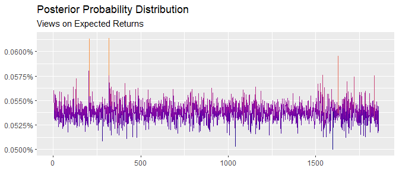

```r
autoplot(ep) +
  scale_color_viridis_c(option = "C", end = 0.75) +
  labs(title    = "Posterior Probability Distribution",
       subtitle = "Views on Expected Returns",
       x        = NULL,
       y        = NULL)
```

The plot reinforces the intuition of $x_j$ - the *posterior* probability - as a distribution that distorts the *prior* in order to accommodate the *views*.

It’s easy to double-check the investor *views* by computing the ratio of the *conditional* vs. *unconditional* returns:

```r
conditional   <- ffp_moments(x, ep)$mu
unconditional <- colMeans(x)

conditional / unconditional - 1
```

```
#>         DAX         SMI         CAC        FTSE
#>  0.01335825  0.02078130 -0.09999999  0.20000009
```

According to expectations, `CAC` outlook is now $10\%$ bellow average and `FTSE` expected return is $20\%$ above average. *Violà!*

## Views on Volatility

Say the investor is confident that markets will be followed by a period of lull and bonanza. Without additional insights about expected returns, the investor anticipates that market volatility for the `CAC` index will drop by $10\%$.

To impose *views* on volatility, the investor needs to minimize the expression:

$$\sum_{j=1}^J x_j(ln(x_j) - ln(p_j))$$
Subject to the constraint:

$$\sum_{j=1}^{J} x_j V_{j, k}^2 =
\mu_{k}^2 + \sigma_{k}^2$$

In which, $x_j$ is a vector of yet to be defined *posterior* probabilities; $V_{j,k}^2$ is a $1859 \times 1$ vector with `CAC` squared returns; $\mu_{k}^2$ and $\sigma_{k}^2$ are the `CAC` sample mean and variance; and $k$ is the column position of `CAC` in the panel $V$.

The `view_on_volatility` function can be used for this purpose:

```r
# opinion
vol_cond <- sd(x[ , "CAC"]) * 0.9

# views
views <- view_on_volatility(x = as.matrix(x[ , "CAC"]), vol = vol_cond)
views
```

```
#> # ffp view
#> Type:  View On Volatility
#> Aeq :  Dim 1 x 1859
#> beq :  Dim 1 x 1
```

The `views` object holds a list with two components - `Aeq` and `beq` - that are equivalent to the elements $V_{j,k}^2$ transposed and $\mu_{k}^2 + \sigma_{k}^2$, respectively.

To solve the relative entropy use the `entropy_pooling` function:

```r
ep <- entropy_pooling(
  p      = p_j,
  Aeq    = views$Aeq,
  beq    = views$beq,
  solver = "nlminb"
)
ep
```

```
#> <ffp[1859]>
#> 0.0005227495 0.0004701207 0.0005609239 0.0005476659 0.0005631671 ... 0.0005349393
```

Once again, the `ep` vector is what we call *posterior*: the probability vector that causes the “least” amount of distortion in the *prior*, but still obeys the constraints (*views*).

The *posterior* probabilities can be observed with the `autoplot` method:

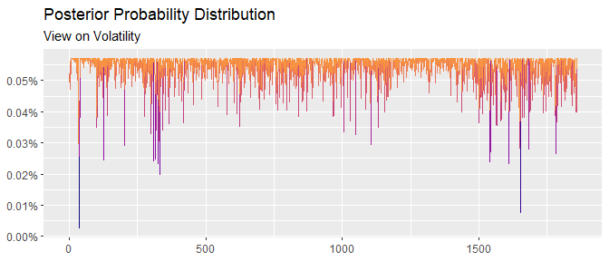

```r
autoplot(ep) +
  scale_color_viridis_c(option = "C", end = 0.75) +
  labs(title    = "Posterior Probability Distribution",
       subtitle = "View on Volatility",
       x        = NULL,
       y        = NULL)
```

To check if the *posterior* probabilities are valid as a way to display the investor’s *view*, compare the *conditional* vs. *unconditional* volatilities:

```r
unconditional <- apply(x, 2, sd)
conditional   <- sqrt(diag(ffp_moments(x, ep)$sigma))

conditional / unconditional - 1
```

```
#>         DAX         SMI         CAC        FTSE
#> -0.08377407 -0.06701178 -0.09977906 -0.04552477
```

The *posterior* volatility for the `CAC` index is reduced by $10\%$, in line with the investor’s subjective judgment. However, by emphasizing tranquil periods more often, other assets are also affected, but in smaller magnitudes.

## Views on Correlation

Assume the investor believes the correlation between `FTSE` and `DAX` will increase by $30\%$, from $0.64$ to $0.83$. To construct *views* on the correlation matrix, the general expression has to be minimized:

$$\sum_{j=1}^J x_j(ln(x_j) - ln(p_j))$$
Subject to the constraints:

$$\sum_{j=1}^{J} x_j V_{j, k} V_{j, l} =
\mu_{k} \mu_{l} + \sigma_{k} \sigma_{l} C_{k,l}$$

In which, the term $V_{j, k} V_{j, l}$ on the left hand-side of the restriction consists of cross-correlations among assets; the terms $\mu_{k} \mu_{l} + \sigma_{k} \sigma_{l} C_{k,l}$ carry the investor target correlation structure; and $x_j$ is a yet to be defined probability vector.

To formulate this *view*, first compute the *unconditional* correlation matrix. Second, add a “perturbation” in the corresponding element that is consistent with the perceived *view*:

```r
cor_view <- cor(x) # unconditional correlation matrix
cor_view["FTSE", "DAX"] <- 0.83 # perturbation (investor belief)
cor_view["DAX", "FTSE"] <- 0.83 # perturbation (investor belief)
```

Finally, pass the adjusted correlation matrix into the `view_on_correlation` function:

```r
views <- view_on_correlation(x = x, cor = cor_view)
views
```

```
#> # ffp view
#> Type:  View On Correlation
#> Aeq :  Dim 10 x 1859
#> beq :  Dim 10 x 1
```

In which `Aeq` is equal to $V_{j, k} V_{j, l}$ transposed and `beq` is a $10 \times 1$ vector with $\mu_{k} \mu_{l} + \sigma_{k} \sigma_{l} C_{k,l}$.

Notice that even though the investor has a *view* in just one parameter[^4] the constraint vector has $10$ rows, because every element of the lower/upper diagonal of the correlation matrix has to match.

Once again, the minimum entropy is solved by `entropy_pooling`:

```r
ep <- entropy_pooling(
  p      = p_j,
  Aeq    = views$Aeq,
  beq    = views$beq,
  solver = "nlminb"
)
ep
```

```
#> <ffp[1859]>
#> 6.709143e-05 0.000659403 0.001085763 0.0003254822 0.0005215729 ... 0.0004748052
```

And the `autoplot` method is available:

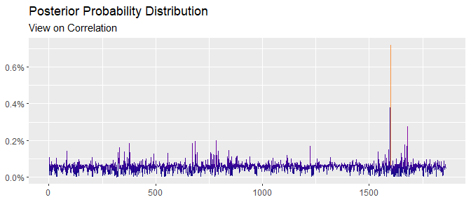

```r
autoplot(ep) +
  scale_color_viridis_c(option = "C", end = 0.75) +
  labs(title    = "Posterior Probability Distribution",
       subtitle = "View on Correlation",
       x        = NULL,
       y        = NULL)
```

To fact-check the investor *view*, compute the *posterior* correlation matrix:

```r
cov2cor(ffp_moments(x, p = ep)$sigma)
```

```
#>            DAX       SMI       CAC      FTSE
#> DAX  1.0000000 0.6932767 0.7317714 0.8346939
#> SMI  0.6932767 1.0000000 0.6260098 0.6113109
#> CAC  0.7317714 0.6260098 1.0000000 0.6535585
#> FTSE 0.8346939 0.6113109 0.6535585 1.0000000
```

And notice that the linear association between `FTSE` and `DAX` is now $0.83$!

## Views on Relative Performance

Assume the investor believes the `DAX` index will outperform the `SMI` by some amount, but he doesn’t know by how much. If the investor has only a mild *view* on the performance of assets, he may want to minimize the following expression:

$$\sum_{j=1}^J x_j(ln(x_j) - ln(p_j))$$
Subject to the constraint:

$$\sum_{j=1}^{J} x_j (V_{j, k} - V_{j,
l}) \ge 0$$
In which, the $x_j$ is a yet to be determined probability vector; $V_{j, k}$ is a $1859 \times 1$ column vector with `DAX` returns and $V_{j, l}$ is a $1859 \times 1$ column vector with the `SMI` returns. In this case, the $k$ and $l$ subscripts refers to the column positions of `DAX` and `SMI` in the object `x`, respectively.

*Views* on relative performance can be imposed with `view_on_rank`:

```r
views <- view_on_rank(x = x, rank = c(2, 1))
views
```

```
#> # ffp view
#> Type:  View On Rank
#> A :  Dim 1 x 1859
#> b :  Dim 1 x 1
```

Assets that are expected to outperform enter in the `rank` argument with their column positions to the right: assets in the left underperform and assets in the right outperform. Because the investor believes that `DAX` $\geq$ `SMI` (the asset in the first column will outperform the asset in the second column), we fill `rank = c(2, 1)`[^5].

The optimization is, once again, guided by the `entropy_pooling` function:

```r
ep <- entropy_pooling(
  p      = p_j,
  A      = views$A,
  b      = views$b,
  solver = "nloptr"
)
ep
```

```
#> <ffp[1859]>
#> 0.0005145646 0.0005403155 0.0005470049 0.0005330238 0.0005446858 ... 0.0005469164
```

Two important observations:

- Inequalities constraint cannot be handled with the `nlminb` solver. Use `nloptr` or `solnl`, instead;
- Inequalities constraint require the arguments `A` and `b` to be fulfilled rather than `Aeq` and `beq`.

The *posterior* probabilities are presented bellow:

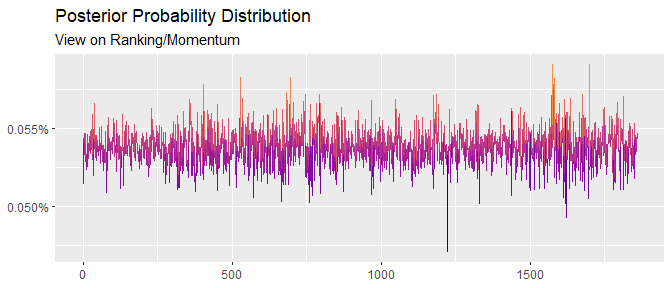

```r
autoplot(ep) +
  scale_color_viridis_c(option = "C", end = 0.75) +
  labs(title    = "Posterior Probability Distribution",
       subtitle = "View on Ranking/Momentum",
       x        = NULL,
       y        = NULL)
```

To fact-check the ongoing *view*, compare the *conditional* vs. *unconditional* returns:

```r
conditional   <- ffp_moments(x, ep)$mu
unconditional <- colMeans(x)

conditional / unconditional - 1
```

```
#>         DAX         SMI         CAC        FTSE
#>  0.17274275 -0.06507207  0.13576463  0.06261163
```

Indeed, returns for `DAX` are adjusted upwards by $17\%$, while returns for `SMI` are revised downwards by $6.5\%$. Notice that returns for `CAC` and `FTSE` were also affected. This behavior could be tamed by combining the ranking condition with *views* on expected returns. See the function `bind_views()` for an example.

## Views on Marginal Distribution

Assume the investor has a *view* on the entire marginal distribution. One way to add *views* on marginal distributions is by matching the first moments exactly, up to a given order. Mathematically, the investor minimizes the relative entropy:

$$\sum_{j=1}^J x_j(ln(x_j) - ln(p_j))$$
With, say, two equality constraints (one for $\mu$ and one for $\sigma^2$):

$$\sum_{j=1}^J x_j
V_{j,k} = \sum_{j=z}^Z p_z \hat{V}_{z,k}$$
$$\sum_{j=1}^J x_j (V_{j,k})^2 = \sum_{z=1}^Z
p_z (\hat{V}_{z,k})^2$$

In which $x_j$ is a yet to be defined probability vector; $V_{j,k}$ is a matrix with the empirical marginal distributions; $p_z$ is vector of *prior* probabilities; and $\hat{V}_{z,k}$ an exogenous panel with simulations that are consistent with the investor’s *views*.

When $j = z$, the panels $V_{j,k}$ and $\hat{V}_{z,k}$ have the same number of rows and the dimensions in both sides of the restrictions match. However, it’s possible to set $z \ge j$ to simulate a larger panel for $\hat{V}_{z, k}$. Keep in mind though that, if $z \ne j$, two *prior* probabilities will have to be specified: one for $p_j$ (the objective function) and one for $p_z$ (the *views*).

Continuing on the example, consider the margins of `x` can be approximated by a symmetric multivariate t-distribution. If this is the case, the estimation can be conducted by the amazing `ghyp` package, that covers the entire family of [generalized hyperbolic distributions](https://en.wikipedia.org/wiki/Generalised_hyperbolic_distribution):

```r
library(ghyp)

# multivariate t distribution
dist_fit <- fit.tmv(data = x, symmetric = TRUE, silent = TRUE)
dist_fit
```

```
#> Symmetric Student-t Distribution:
#>
#> Parameters:
#>       nu
#> 6.151241
#>
#> mu:
#> [1] 0.0007899665 0.0009594760 0.0004790250 0.0003811669
#>
#> sigma:
#>               DAX          SMI          CAC         FTSE
#> DAX  1.000013e-04 6.046969e-05 7.933384e-05 5.072439e-05
#> SMI  6.046969e-05 8.062728e-05 5.869208e-05 4.119624e-05
#> CAC  7.933384e-05 5.869208e-05 1.216927e-04 5.715865e-05
#> FTSE 5.072439e-05 4.119624e-05 5.715865e-05 6.398099e-05
#>
#> gamma:
#> [1] 0 0 0 0
#>
#> log-likelihood:
#> 26370.73
#>
#>
#> Call:
#> fit.tmv(data = x, symmetric = TRUE, silent = TRUE)
```

The investor then, can construct a large panel with statistical properties similar to the margins he envisions:

```r
set.seed(123)
# random numbers from `dist_fit`
simul  <- rghyp(n = 100000, object = dist_fit)
```

Where the $100.000 \times 4$ matrix is used to match the *views* with `view_on_marginal_distribution`:

```r
p_z <- rep(1 / 100000, 100000)
views <- view_on_marginal_distribution(
  x     = x,
  simul = simul,
  p     = p_z
)
views
```

```
#> # ffp view
#> Type:  View On Marginal Distribution
#> Aeq :  Dim 8 x 1859
#> beq :  Dim 8 x 1
```

The objects `simul` and `p_z` corresponds to the terms $\hat{V}_{z,k}$ transposed and $p_z$, respectively. Note that $8$ restrictions are created, four for each moment of the marginal distribution (there are four assets in “the market”).

With the *prior* and the *views* at hand, the optimization can be quickly implemented:

```r
ep <- entropy_pooling(
  p      = p_j,
  Aeq    = views$Aeq,
  beq    = views$beq,
  solver = "nloptr"
)
ep
```

```
#> <ffp[1859]>
#> 0.000528748 0.0005678894 0.000536657 0.0005231905 0.0005349765 ... 0.0005324979
```

As the visual inspection of the vector `ep`:

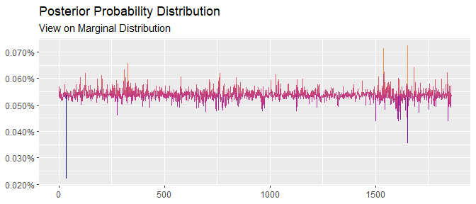

```r
autoplot(ep) +
  scale_color_viridis_c(option = "C", end = 0.75) +
  labs(title    = "Posterior Probability Distribution",
       subtitle = "View on Marginal Distribution",
       x        = NULL,
       y        = NULL)
```

It’s easy to extend the current example. For instance, the investor could “tweak” some of the fitted parameters for stress-testing (i.e. change the degrees of freedom, increase/decrease expected returns, etc) to verify the immediate impact on the P&L (VaR, CVaR, etc).

Acknowledge that when the restrictions are to harsh, the scenarios will be heavily distorted to satisfy the *views*. In this case, one may need to compute the effective number of scenarios (ENS). This is very easy to do with `ens()`:

```r
ens(ep)
```

```
#> [1] 1857.356
```

Rest on the investor to calibrate this statistic in order to get a desired confidence level[^6].

## Views on Copulas

Assume the investor would like to simulate a different dependence structure for the market. *Views* that change the interdependence of assets can be implemented by minimizing the relative entropy:

$$\sum_{j=1}^J x_j(ln(x_j) - ln(p_j))$$
Subject to the following restrictions:

$$\sum_{j=1}^J x_i U_{j,k} = 0.5$$
$$\sum_{j=1}^J x_j U_{j,k}U_{j,l} = \sum_{z=1}^Z
p_z \hat{U}_{z,k}\hat{U}_{z,l}$$

$$\sum_{j=1}^J x_j
U_{j,k}U_{j,l}U_{j,i} = \sum_{j=1}^J p_j
\hat{U}_{j,k}\hat{U}_{j,l}\hat{U}_{j,i}$$

In which, the first restriction matches the first moment of the uniform distribution; the second and third restrictions pair the cross-moments of the empirical copula, $U$, with the simulated copula, $\hat{U}$; $x_j$ is a yet to be discovered *posterior* distribution; $p_z$ is a *prior* probability; When $j = z$, the dimensions of $p_j$ and $p_z$ match.

Among many of the available copulas, say the investor wants to model the dependence of the market as a clayton copula to ensure the lower [tail dependency](https://en.wikipedia.org/wiki/Tail_dependence) does not go unnoticed. The estimation is simple to implement with the package `copula`:

```r
library(copula)

# copula (pseudo-observation)
u <- pobs(x)

# copula estimation
cop <- fitCopula(
  copula = claytonCopula(dim = ncol(x)),
  data   = u,
  method = "ml"
)

# simulation
r_cop <- rCopula(
  n      = 100000,
  copula = claytonCopula(param = cop@estimate, dim = 4)
)
```

First, the copulas are computed component-wise by applying the marginal empirical distribution in every $k$ column of the dataset. Second, the pseudo-observations are used to fit a Clayton copula by the Maximum-Likelihood (ML) method. Finally, a large panel with dimension $100.000 \times 4$ is constructed to match a Clayton copula with $\hat \alpha = 1.06$, as in the object `cop`.

The *views* on the market is constructed with the `view_on_copula`:

```r
views <- view_on_copula(x = u, simul = r_cop, p = p_z)
views
```

```
#> # ffp view
#> Type:  View On Copula
#> Aeq :  Dim 34 x 1859
#> beq :  Dim 34 x 1
```

Once again, the solution of the minimum relative entropy can be found in one line of code:

```r
ep <- entropy_pooling(
  p      = p_j,
  Aeq    = views$Aeq,
  beq    = views$beq,
  solver = "nloptr"
)
ep
```

```
#> <ffp[1859]>
#> 0.0001990935 0.0004161479 0.0008166059 0.0006512624 0.0003776943 ... 0.0003269579
```

And the `autoplot` method is available for the objects of the `ffp` class:

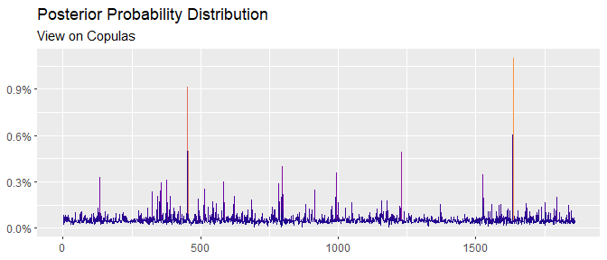

```r
autoplot(ep) +
  scale_color_viridis_c(option = "C", end = 0.75) +
  labs(title    = "Posterior Probability Distribution",
       subtitle = "View on Copulas",
       x        = NULL,
       y        = NULL)
```

To stretch the current example, assume the investor stresses the parameter $\hat \alpha = 1.06$[^7]. Higher $\alpha$ values are linked to extreme occurrences on the left tails of the distribution. Whence, consider the case where $\hat \alpha = 5$:

```r
cop@estimate <- 5
```

Rerun the previous steps (simulation, *views* and optimization):

```r
# simulation
r_cop <- rCopula(
  n      = 100000,
  copula = claytonCopula(param = cop@estimate, dim = 4)
)

# #views
views <- view_on_copula(x = u, simul = r_cop, p = p_z)

# relative entropy
ep <- entropy_pooling(
  p      = p_j,
  Aeq    = views$Aeq,
  beq    = views$beq,
  solver = "nloptr"
)
```

To find the new *posterior* probability vector the satisfy the stress-test condition:

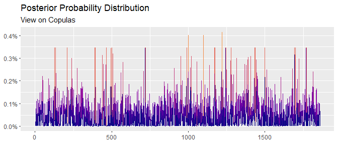

```r
autoplot(ep) +
  scale_color_viridis_c(option = "C", end = 0.75) +
  labs(title    = "Posterior Probability Distribution",
       subtitle = "View on Copulas",
       x        = NULL,
       y        = NULL)
```

[^1]: Meucci, Attilio, Fully Flexible Views: Theory and Practice (August 8, 2008). Fully Flexible Views: Theory and Practice, Risk, Vol. 21, No. 10, pp. 97-102, October 2008, Available at SSRN: https://www.ssrn.com/abstract=1213325
[^2]: The commands `x[ , 4]` or `x[ , "FTSE"]` yield the same results.
[^3]: An ARIMA, GARCH or VAR model could be used as well. The focus is not on the best forecasting method, but how to input the *view* once the forecast has already been made.
[^4]: `cor(ftse, dax) = 0.83`.
[^5]: In the `x` object, `DAX` it’s in the first column and the `SMI` it’s in the second column.
[^6]: Meucci, Attilio, Effective Number of Scenarios in Fully Flexible Probabilities (January 30, 2012). GARP Risk Professional, pp. 32-35, February 2012, Available at SSRN: https://www.ssrn.com/abstract=1971808.
[^7]: `cop@estimate`